# R Notebook

# Dataset

```r
a <- read.csv(url("http://tinyurl.com/2s432xv6")) %>%
  select(seqn, qsmk, sex, age, income, sbp, dbp, price71, tax71, race, wt82_71) %>%
  na.omit()

dim(a)
```

```
[1] 1394   11
```

```r
names(a)
```

```
 [1] "seqn"    "qsmk"    "sex"     "age"     "income"  "sbp"     "dbp"     "price71"
 [9] "tax71"   "race"    "wt82_71"
```

```r
head(a)
```

|  | seqn | qsmk | sex | age | income | sbp | dbp | price71 | tax71 | race | wt82_71 |
| --- | --- | --- | --- | --- | --- | --- | --- | --- | --- | --- | --- |
| 1 | 233 | 0 | 0 | 42 | 19 | 175 | 96 | 2.183594 | 1.1022949 | 1 | -10.093960 |
| 2 | 235 | 0 | 0 | 36 | 18 | 123 | 80 | 2.346680 | 1.3649902 | 0 | 2.604970 |
| 3 | 244 | 0 | 1 | 56 | 15 | 115 | 75 | 1.569580 | 0.5512695 | 1 | 9.414486 |
| 4 | 245 | 0 | 0 | 68 | 15 | 148 | 78 | 1.506592 | 0.5249023 | 1 | 4.990117 |
| 5 | 252 | 0 | 0 | 40 | 18 | 118 | 77 | 2.346680 | 1.3649902 | 0 | 4.989251 |
| 6 | 257 | 0 | 1 | 43 | 11 | 141 | 83 | 2.209961 | 1.1547852 | 1 | 4.419060 |

```r
write_csv(a, here("data", "nhefs.csv"))
```

# Causal Inference

## Associated Risk Difference

Quantifying the causal risk difference -

Start by quantifying the associational risk difference.

Which estimator should we choose, and why? - OLS - ML (max. likelihood) + Poisson, binomial, etc. - GMM (generalized method of moments) - AIPW (augmented inverse probability weight)

Choosing the estimator should be a separate task from finding the effect that we’re interested in. Many different estimators can result in the same point estimate, even if the methods are very different.

# Propensity Scores

Checking for positivity:

```r
library(MatchIt)

data("lalonde")

head(lalonde)

propensity_score <- glm(treat ~ age + educ + re74 + re75,
                        data = lalonde,
                        family = binomial(link = "logit"))$fitted.values

## fitted.values gives you the probability that x = 1
### P(x = 1|C)

head(propensity_score)
```

[output not shown]

```
Warning: Removed 4 rows containing missing values (geom_bar).
```

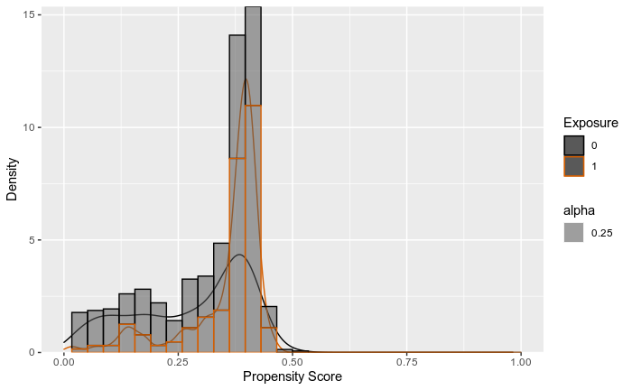

```r
p1
```

You want to see that the densities largely overlap. If the peaks of the curves are in different places (a violation of the positivity assumption), that means that there is very low propensity for one group where there is high propensity for the other group, and there is not propensity overlap. This can be caused by a covariate perfectly predicting treatment, which leads to poor balance if matching without replacement and poor precision if matching with replacement.

Creating stabilized inverse probability weights:

```r
sw <- (mean(exposure)/propensity_score) *
  exposure + ((1 - mean(exposure)) / (1 - propensity_score)) * (1 - exposure)

summary(sw)
```

```
   Min. 1st Qu.  Median    Mean 3rd Qu.    Max.
 0.6548  0.7788  0.9340  1.0451  1.1245 27.6692
```

The mean should be close to 1, and the max should not be too large relative to the original sample size (open to interpretation). Here, 1 person will count as a total of 30 people in the weighted analysis, which is not too large relative to the sample size of around 600.

# Parametric Regression

## Conditionally Asjusted Parametric Regression

Used when we have a set of confounders that we want to adjust for to maximize the chances that exchangeability holds.

```r
nhefs <- read_csv(here("data", "nhefs.csv")) %>%
  mutate(wt_delta = as.numeric(wt82_71 > median(wt82_71)))
dim(nhefs)
```

```
[1] 1394   12
```

```r
names(nhefs)
```

```
 [1] "seqn"     "qsmk"     "sex"      "age"      "income"
 [6] "sbp"      "dbp"      "price71"  "tax71"    "race"
[11] "wt82_71"  "wt_delta"
```

```r
# start fitting regression models to the data

formulaVars <- "qsmk + sex + age + income + sbp + dbp + price71 + tax71 + race"

modelForm <- as.formula(paste0("wt_delta ~", formulaVars))
modelForm
```

```
wt_delta ~ qsmk + sex + age + income + sbp + dbp + price71 +
    tax71 + race
```

```r
# below model can be used to quantify a conditionally adjusted odds
# ratio with correct standard error

modelOR <- glm(modelForm, data = nhefs, family = binomial("logit"))

summary(modelOR)
```

```
Call:
glm(formula = modelForm, family = binomial("logit"), data = nhefs)

Deviance Residuals:
     Min        1Q    Median        3Q       Max
-1.85551  -1.13231   0.01881   1.11506   1.83621

Coefficients:
             Estimate Std. Error z value Pr(>|z|)
(Intercept) -0.822736   1.178775  -0.698 0.485203
qsmk         0.594853   0.133325   4.462 8.13e-06 ***
sex          0.126227   0.113976   1.107 0.268084
age         -0.033421   0.005579  -5.991 2.09e-09 ***
income       0.027180   0.022297   1.219 0.222846
sbp         -0.004227   0.004232  -0.999 0.317912
dbp          0.027001   0.006978   3.870 0.000109 ***
price71      0.121377   0.837939   0.145 0.884828
tax71       -0.193909   0.886114  -0.219 0.826782
race        -0.304103   0.175398  -1.734 0.082956 .
---
Signif. codes:  0 ‘***’ 0.001 ‘**’ 0.01 ‘*’ 0.05 ‘.’ 0.1 ‘ ’ 1

(Dispersion parameter for binomial family taken to be 1)

    Null deviance: 1932.5  on 1393  degrees of freedom
Residual deviance: 1828.0  on 1384  degrees of freedom
AIC: 1848

Number of Fisher Scoring iterations: 4
```

```r
broom::tidy(modelOR)[2, ]
```

| term | estimate | std.error | statistic | p.value |
| --- | --- | --- | --- | --- |
| qsmk | 0.5948532 | 0.1333246 | 4.46169 | 8.131565e-06 |

Two problems here: 1. Estimating a conditional odds ratio (and the OR is a non-collapsible measure of effect) 2. Interactions

**Marginally adjusted effects** are like ATE - averaged over the sample, essentially standardized to the distribution. (The effect that would be observed)Population average effect)

**Conditionally adjusted effects** are different, and in the case of the OR, the differences matter. (The effect of the exposure, if you were to hold all values of confounders to a fixed, constant level) - Problematic to interpret because we don’t know what the value is that we’re holding constant

**We really should be focusing on marginally adjusted effects only because their interpretation is much more specific and clear.** They are unaffected by collapsibility or non-collapsibility. Marginal ORs are better than conditional ORs, but ultimately you’re better off estimating a risk difference or risk ratio.

**Non-collapsibilty** is a term used to describe the consequences of mathematical inequality called Jensen’s inequality - describes some function of the expectation of a random variable is going to be greater than the expectation of a function of a random variable + f[E(x)] > E[f(x)] - w/ re: to logistic regression, that f(x) is the logit or log odds function + logit = log[P / (1 - P)]

Conditional OR is usually greater than marginal OR, and maximiallythe greatest when the prevalence of the outcome is aaround 50% - cOR > mOR - The difference would be smaller if the outcome is rare.

**Interactions problem** If you do have interactions, you know you need to include them, and they involve the exposure, interpreting the coef becomes much more challenging.

Once you put the interaction in, you’ll have terms that include the coefs for the interaction value. To get the overall effect, you have to combine the magnitude of the coef for this interaction w/ the magnitude of the coef for your exposure.

This is not too problematic for a single coef, but as we think more globally about all possible interactions and variables, eventually (if your interest is the overall effect in the population) doing that math becomes very tedious and prone to error.

**Methods to estimate marginally adjusted effects** can mitigate these issues.

The risk difference in the risk ratio are collapsible measures, meaning the marginally adjusted effect is the same as the conditionally adjusted effect IF all of the interactions are properly taken into account. - switch “logit” to “identity” - this does not address the interactions problem

## Marginally Adjusted Parametric Regression

Marginal standardization or marginal adjustment is a procedure that allows us to use regression to generate predictions under different scenarios, then compute the differences between them.

It is equivalent to G-computation / parametric G formula / model-based standardization when the exposure is measured at a single time point.

```r
# regress outcome against confounders w/o interaction
ms_model <- glm(modelForm,
                data = nhefs,
                family = binomial("logit"))

# generate preds for everyone in the sample to obtain unexposed
# (mu0 preds) and exposed (mui presd) risks
mu1 <- predict(ms_model,
               newdatae = transform(nhefs, qsmk = 1),
               type = "response")

mu0 <- predict(ms_model,
               newdata = transform(nhefs, qsmk = 0),
               type = "response")

# marginally adjusted odds ratio
marg_stand_OR <- (mean(mu1)/mean(1-mu1))/(mean(mu0)/mean(1-mu0))

# marginally adjusted risk ratio
marg_stand_RR <- mean(mu1)/mean(mu0)

# marginally adjusted risk difference
marg_stand_RD <- mean(mu1) - mean(mu0)

# use the bootstrap to obtain the CIs for the marginally adjusted
# RR and RD
bootfunc <- function(data, index) {
  boot_dat <- data[index, ]
  ms_model <- glm(modelForm,
                  data = boot_dat,
                  family = binomial("logit"))
  mu1 <- predict(ms_model,
                 newdata = transform(boot_dat,
                                      qsmk = 1),
                 type = "response")
  mu0 <- predict(ms_model,
                 newdata = transform(boot_dat,
                                      qsmk = 0),
                 type = "response")

  marg_stand_OR_ <- (mean(mu1)/mean(1-mu1))/(mean(mu0)/mean(1-mu0))
  marg_stand_RR_ <- mean(mu1)/mean(mu0)
  marg_stand_RD_ <- mean(mu1) - mean(mu0)
  res <- c(marg_stand_RD_, marg_stand_RR_, marg_stand_OR_)
  return(res)
}

# run the boot fn
# set seed for reproducibility
set.seed(123)

boot_res <- boot(nhefs, bootfunc, R = 2000)

boot_RD <- boot.ci(boot_res, index = 1)
boot_RR <- boot.ci(boot_res, index = 2)
boot_OR <- boot.ci(boot_res, index = 3)
marg_stand_OR
```

```
[1] 1.143761
```

```r
marg_stand_RR
```

```
[1] 1.071881
```

```r
marg_stand_RD
```

```
[1] 0.03353019
```

```r
boot_RD
```

```
BOOTSTRAP CONFIDENCE INTERVAL CALCULATIONS
Based on 2000 bootstrap replicates

CALL :
boot.ci(boot.out = boot_res, index = 1)

Intervals :
Level      Normal              Basic
95%   ( 0.0793,  0.1966 )   ( 0.0802,  0.1976 )

Level     Percentile            BCa
95%   ( 0.0779,  0.1953 )   ( 0.0779,  0.1952 )
Calculations and Intervals on Original Scale
```

```r
boot_RR
```

```
BOOTSTRAP CONFIDENCE INTERVAL CALCULATIONS
Based on 2000 bootstrap replicates

CALL :
boot.ci(boot.out = boot_res, index = 2)

Intervals :
Level      Normal              Basic
95%   ( 1.158,  1.431 )   ( 1.156,  1.428 )

Level     Percentile            BCa
95%   ( 1.163,  1.435 )   ( 1.163,  1.435 )
Calculations and Intervals on Original Scale
```

```r
boot_OR
```

```
BOOTSTRAP CONFIDENCE INTERVAL CALCULATIONS
Based on 2000 bootstrap replicates

CALL :
boot.ci(boot.out = boot_res, index = 3)

Intervals :
Level      Normal              Basic
95%   ( 1.302,  2.162 )   ( 1.266,  2.125 )

Level     Percentile            BCa
95%   ( 1.367,  2.227 )   ( 1.367,  2.224 )
Calculations and Intervals on Original Scale
```

**Interpreting risk difference** If you want to interpret RD as a causal measure, you have to ensure that you have: counterfactual consistency, no interference, exchangeability, and positivity.

After getting result, explore assumptions using the data: - Counterfactual consistency: you can identify some intervention that allows you to set people to the exposure value or the un-exposure value + In this case, it is not grossly violated because we can’t tell people to quite smoking (?) - No interference + In this case, we don’t know if multiple people live in the same house/environment and whether interference might be a problem - Exchangeability: Are we satisfied with all of our confounding variables, or are there others we might adjust for? Is there missing data (selection bias)? Is there potential measurement error? + We removed observations with missing data so we have potential selection bias. - Positivity: Distribution of propensity scores and stabilized weights (see above) + In this case, not perfect, but not terrible

These items become elements of discussion when interpreting the results, rather than immediately disqualifying.

These assumptions are not objectively verifiable - they rely on what we know about the world, what we believe we know about the world.

## Marginal Standardization

```r
# see pdf
```

**Always lean towards using stratified modeling approach** This approach contains within it the un-stratified approach, essentially. It fits two separate models without forcing the parameters to be different if they aren’t, but allowing them to be different if they are. Stratified is more general.

The only issue with the stratified approach may be when working with smaller sample sizes, which may result in wider CIs.

The approaches having similar results also doesn’t mean that either/both approaches are “right”.

## Propensity Score Methods

See PDFs

## Inverse Probability Weighting

See PDFs

# Intro to the Super Learner

Basically just a stacking algorithm.

Benefits: - Performance is no worse than that of the best algorithm/model - It simplifies things tremendously + Avoids needing to tune individual algorithms/models

## Mechanics of Super Learner

Estimating a Dose-Responsive Curve

```r
library(rmutil)
library(here)
library(SuperLearner)
```

```r
set.seed(123)

# generate data
n = 1000
x = runif(n, 0, 8)
y = 5 + 4 * sqrt(9 * x) * as.numeric(x < 2) + as.numeric(x >= 2) * (abs(x - 6)^(2)) + rlaplace(n)

# to plot the true dose-responsive curve, generate sequence of 'doses' from 0
# to 8 at ever 0.1, then generate the true outcome
x1 <- seq(0, 8, 0.1)
y1 <- 5 + 4 * sqrt(9 * x1) * as.numeric(x1 < 2) + as.numeric(x1 >= 2) * (abs(x1 - 6)^(2))

D <- data.frame(x, y)
D1 <- data.frame(x1, y1)

head(D)
```

|  | x | y |
| --- | --- | --- |
| 1 | 2.300620 | 18.082553 |
| 2 | 6.306441 | 5.301833 |
| 3 | 3.271815 | 11.304711 |
| 4 | 7.064139 | 7.359499 |
| 5 | 7.523738 | 8.510791 |
| 6 | 0.364452 | 12.199149 |

Consider two “level-zero” algorithms (for simplicity): - Generalized additive models with 5-knot natural cubic splines (gam package) - Multivariate adaptive regression splines (earth package)

Using mean squared error as loss function to measure how well the model is performing.

Using 5-fold cross-validation to avoid over-fitting.

```r
# specify number of folds
folds = 5

## split data into 5 groups for 5-fold cross-validation
index <- split(1:1000, 1:folds)
splt <- lapply(1:folds, function(ind) D[index[[ind]],])

head(splt[[1]])
```

|  | x | y |
| --- | --- | --- |
| 1 | 2.300620 | 18.082553 |
| 6 | 0.364452 | 12.199149 |
| 11 | 7.654667 | 7.659093 |
| 16 | 7.198600 | 7.229326 |
| 21 | 7.116315 | 6.165418 |
| 26 | 5.668244 | 4.659275 |

```r
head(splt[[2]])
```

|  | x | y |
| --- | --- | --- |
| 2 | 6.306441 | 5.301833 |
| 7 | 4.224844 | 8.943891 |
| 12 | 3.626673 | 10.249762 |
| 17 | 1.968702 | 21.964325 |
| 22 | 5.542427 | 6.089999 |
| 27 | 4.352528 | 7.891969 |

Fit using the SuperLearner package:

```r
# create the 5 df GAMs
SL.gam.5 <- create.Learner("SL.gam", params = list(deg.gam = 5))

# specify the SuperLearner library of candidate algorithms
sl.lib <- c(SL.gam.5$names, "SL.earth")

# fit using SuperLearner package, specify outcome-for-prediction (y), the predicotr (x),
# the loss function (L2), the library (sl.lib), and the number of folds
fitY <- SuperLearner(Y = y,
                     X = data.frame(x),
                     method = "method.NNLS",
                     SL.library = sl.lib,
                     cvControl = list(V = folds, validRows = index))

# view the output: 'Risk' column returns the CV-MSE estimates
# the 'Coef' column gives the weights for the final SuperLearner (meta-learner)
fitY

# now predict the outcome for all possible x 'doses'
yS <- predict(fitY,
              newdata = data.frame(x = x1),
              onlySL = T)$pred

# create df of all x 'doses' and predict SL reponses
Dl1 <- data.frame(x1, yS)
```

[output not shown]

## sl3 Implementation